# Hito 1 - Grupo 11

Vicente Guzmán, Ignacio Muñoz, José Arriagada, Nicolás Gonzalez y Javier Atenas

24 de Abril 2023

CC5205 - Minería de Datos  
Prof. Felipe Bravo y Hernán Sarmiento

# Introducción

Steam es la plataforma líder de distribución digital de videojuegos en PC, y este mercado cada vez tiene más consumidores y va ganando terreno por sobre otras formas de entretención. Esto lo demuestra su co-fundador Gabe Newell, el cual con su plataforma es uno de los 1000 hombres más ricos del mundo. Siendo este un mercado en constante cambio con millones de usuarios, vale la pena investigar sobre su contenido, junto a sus ascensos y caídas. Estudiar este dataset podría ayudar a entender las preferencias en el mercado de los videojuegos, cuáles son los más vendidos y cuáles tienen las mejores valoraciones, entre otros estudios.

# Exploración de Datos

Este dataset posee datos de más de 27.000 juegos y algunos pocos softwares estrenados hasta el 2019 en formato CSV. Tiene datos como el nombre, la descripción, la categoría, el género, los logros de cada juego, la fecha de lanzamiento, el desarrollador, el *publisher*, la edad requerida para jugar el juego, la cantidad de gente que posee el juego, el precio, el promedio del tiempo de juego de los usuarios y la puntuación positivas y negativa de los usuarios. Por como está definido este dataset, la columna “género”, al ser de tipo string, cualquier dato que se encuentre es un tipo diferente, a menos que sea exactamente igual a otro. (Ej: “action” es un género diferente a “action;Indie”, a pesar de que a nuestro entendimiento, si son del mismo género). Por lo que si se quisiera revisar todos los juegos que sean del género “action”, saldrían solamente aquellos juegos que tuviesen como único género “action”. Esto ocurre con varias columnas, por lo que a futuro, se tendrá que modificar o encontrar una forma, para lograr encontrar de manera efectiva varios datos específicos que quisiéramos ver.

# Preguntas y Problemas

- ¿Cuáles son los géneros que generan más ingresos?
- ¿Qué géneros tienen un mejor porcentaje de reviews positivas?
- ¿Existe una relación entre el tiempo promedio de juego y sus reviews?  
  Hipótesis: Hay una relación directa entre las reviews de un juego y tiempo de juego, ya que si un jugador no disfruta un juego y le escribe una mala review, tampoco querrá jugarlo, por lo tanto los juegos con altos tiempos de juego tendrán mejores reviews.
- ¿Qué relación hay entre el precio de un juego y su tiempo de juego promedio?  
  Hipótesis: Hay una relación directa entre el precio de un juego y tiempo de juego, ya que los usuarios “harán valer” el dinero invertido, haciendo que jueguen un juego caro mucho más que uno gratis, para sentir que valió la pena.
- ¿Los juegos con más logros tienen más tiempo de juego que los juegos con menos logros?
- ¿Los *publishers* influyen en la cantidad de ventas de un juego?  
  Hipótesis: Si, pues los *publishers* más conocidos harán que el juego se destaque más en el mercado, pues da el sello de garantía de que ellos lo aprobaron, y si la gente confía en ellos, confiarán en este nuevo juego. Mientras que los *indies* tienen menos base de publicidad.

# Contribuciones de cada miembro del equipo

Vicente Guzmán estuvo a cargo de la creación del GitHub en el cual se almacena el dataset y el informe en R. Ayudó en la creación del código fuente.  
Ignacio Muñoz creó la presentación del hito 1, junto con aportar en la creación de preguntas y motivación.  
José Arriagada ayudó en la motivación y en la creación de las preguntas y sus hipótesis.  
Nicolás González halló y buscó solución para el problema a futuro de trabajar con el dataset. Además, aportó en la sección de motivación.  
Javier Atenas creó los documentos y carpetas iniciales del proyecto. Aportó en la sección de preguntas y problemas, junto a las hipótesis de estos mismos.

# Código Fuente

Se anexa el código fuente utilizado para la exploración de datos con su respectiva función.

#### Dataset de los juegos de Steam

```r
# Asignamos nuestro "working directory" (set w. d.) como el directorio ~/RDATA
setwd("C:/Users/elviz/Desktop/UChile/9no/mineria/Proyecto-Mineria-2023-1/db")
steam <- read.csv("steam.csv")
head(steam)
```

```
##   appid                      name release_date english        developer
## 1    10            Counter-Strike   2000-11-01       1            Valve
## 2    20     Team Fortress Classic   1999-04-01       1            Valve
## 3    30             Day of Defeat   2003-05-01       1            Valve
## 4    40        Deathmatch Classic   2001-06-01       1            Valve
## 5    50 Half-Life: Opposing Force   1999-11-01       1 Gearbox Software
## 6    60                  Ricochet   2000-11-01       1            Valve
##   publisher         platforms required_age
## 1     Valve windows;mac;linux            0
## 2     Valve windows;mac;linux            0
## 3     Valve windows;mac;linux            0
## 4     Valve windows;mac;linux            0
## 5     Valve windows;mac;linux            0
## 6     Valve windows;mac;linux            0
##                                                                     categories
```

[output cut: 20 more lines]

#### Cantidad de juegos que hay en la base de datos

```r
length(unique(steam$name))
```

```
## [1] 27033
```

#### Cantidad de desarrolladores que hay en la base de datos

```r
length(unique(steam$developer))
```

```
## [1] 17113
```

#### Cantidad de *publishers* que hay en la base de datos

```r
length(unique(steam$publisher))
```

```
## [1] 14354
```

#### Gráfico con las fechas de lanzamiento de los juegos

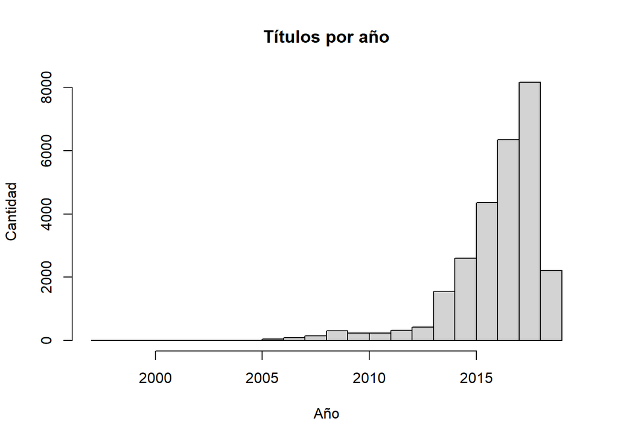

```r
steam$release_date <- as.Date(steam$release_date)
steam$year <- as.numeric(format(steam$release_date, "%Y"))
hist(steam$year, main = "Títulos por año", xlab = "Año", ylab = "Cantidad")
```

#### Juegos que tienen uno o mas géneros en específico

```r
library(dplyr)
steam2 <- steam %>% filter(grepl('Action', genres))
steam3 <- steam %>% filter(grepl('Strategy', genres)&(grepl('RPG', genres)))
head(steam2, 10)
```

```
##    appid                           name release_date english        developer
## 1     10                 Counter-Strike   2000-11-01       1            Valve
## 2     20          Team Fortress Classic   1999-04-01       1            Valve
## 3     30                  Day of Defeat   2003-05-01       1            Valve
## 4     40             Deathmatch Classic   2001-06-01       1            Valve
## 5     50      Half-Life: Opposing Force   1999-11-01       1 Gearbox Software
## 6     60                       Ricochet   2000-11-01       1            Valve
## 7     70                      Half-Life   1998-11-08       1            Valve
## 8     80 Counter-Strike: Condition Zero   2004-03-01       1            Valve
## 9    130          Half-Life: Blue Shift   2001-06-01       1 Gearbox Software
## 10   220                    Half-Life 2   2004-11-16       1            Valve
##    publisher         platforms required_age
## 1      Valve windows;mac;linux            0
## 2      Valve windows;mac;linux            0
## 3      Valve windows;mac;linux            0
```

[output cut: 51 more lines]

```r
head(steam3, 10)
```

```
##    appid                                     name release_date english
## 1   3170          King's Bounty: Armored Princess   2009-11-19       1
## 2   8500                               EVE Online   2010-12-15       1
## 3   8880                            Freedom Force   2009-05-29       1
## 4   8890        Freedom Force vs. the Third Reich   2009-05-29       1
## 5  10270             Disciples III: Reincarnation   2014-02-14       1
## 6  17140                               Hinterland   2008-09-30       1
## 7  23600                          Depths of Peril   2010-11-23       1
## 8  24400   King Arthur - The Role-playing Wargame   2009-11-24       1
## 9  24460            King Arthur: Fallen Champions   2011-09-16       1
## 10 24480 King Arthur II: The Role-Playing Wargame   2012-01-27       1
##                          developer                       publisher
## 1              Katauri Interactive                1C Entertainment
## 2                              CCP                             CCP
## 3                 Irrational Games                              2K
```

[output cut: 62 more lines]

#### Juegos que poseen algún género en especificos

```r
steam4 <- steam %>% filter(grepl('Strategy|Action', genres))
head(steam4,10)
```

```
##    appid                           name release_date english        developer
## 1     10                 Counter-Strike   2000-11-01       1            Valve
## 2     20          Team Fortress Classic   1999-04-01       1            Valve
## 3     30                  Day of Defeat   2003-05-01       1            Valve
## 4     40             Deathmatch Classic   2001-06-01       1            Valve
## 5     50      Half-Life: Opposing Force   1999-11-01       1 Gearbox Software
## 6     60                       Ricochet   2000-11-01       1            Valve
## 7     70                      Half-Life   1998-11-08       1            Valve
## 8     80 Counter-Strike: Condition Zero   2004-03-01       1            Valve
## 9    130          Half-Life: Blue Shift   2001-06-01       1 Gearbox Software
## 10   220                    Half-Life 2   2004-11-16       1            Valve
##    publisher         platforms required_age
## 1      Valve windows;mac;linux            0
## 2      Valve windows;mac;linux            0
## 3      Valve windows;mac;linux            0
```

[output cut: 51 more lines]

#### Juegos que no poseen alguno o mas géneros en especificos

```r
steam5 <- steam %>% filter(!grepl('Action', genres))
steam6 <- steam %>% filter(!grepl('Strategy|Action', genres))
head(steam5, 10)
```

```
##    appid                                name release_date english
## 1   1002                    Rag Doll Kung Fu   2005-10-12       1
## 2   1500                            Darwinia   2005-07-14       1
## 3   1510                              Uplink   2006-08-23       1
## 4   1520                              DEFCON   2006-09-29       1
## 5   1530                          Multiwinia   2008-09-19       1
## 6   1600                    Dangerous Waters   2006-02-07       1
## 7   1610             Space Empires IV Deluxe   2006-02-07       1
## 8   1630    Disciples II: Rise of the Elves    2006-07-06       1
## 9   1640      Disciples II: Gallean's Return   2006-07-06       1
## 10  1670 Iron Warriors: T - 72 Tank Command    2006-07-26       1
##                developer             publisher         platforms required_age
## 1            Mark Healey           Mark Healey           windows            0
## 2  Introversion Software Introversion Software windows;mac;linux            0
## 3  Introversion Software Introversion Software windows;mac;linux            0
```

[output cut: 40 more lines]

```r
head(steam6, 10)
```

```
##    appid                                       name release_date english
## 1   1002                           Rag Doll Kung Fu   2005-10-12       1
## 2   1530                                 Multiwinia   2008-09-19       1
## 3   1700                                Arx Fatalis   2007-04-03       1
## 4   1840                           Source Filmmaker   2012-07-10       1
## 5   1930                    Two Worlds Epic Edition   2009-04-30       1
## 6   2520                 Gumboy - Crazy Adventures™   2006-12-19       1
## 7   2990                                 FlatOut 2™   2006-12-21       1
## 8   3010                                Xpand Rally   2006-08-24       1
## 9   3050                         Xpand Rally Xtreme   2008-10-08       1
## 10  3260 Safecracker: The Ultimate Puzzle Adventure   2007-08-29       1
##                developer             publisher         platforms required_age
## 1            Mark Healey           Mark Healey           windows            0
## 2  Introversion Software Introversion Software       windows;mac            0
## 3         Arkane Studios        Arkane Studios           windows            0
```

[output cut: 62 more lines]